# Signed, Sealed… Paid Faster?

Jovoney Morton

2024

## Project Overview

In this project, I evaluated a courier company’s proposal to include stamped self-addressed (SSA) envelopes with invoices to encourage faster customer payments. Using real-world data from 220 customers who received SSA envelopes, I tested whether this tactic significantly reduced the average payment time — enough to offset the envelope cost and improve cash flow.

## Data Setup

```r
# Load the dataset
SSA <- read.csv("/Users/jovoney/Downloads/SSA.csv")
```

## Exploratory Data Analysis

```r
# Summary statistics
summary(SSA$Payment)
```

```
##    Min. 1st Qu.  Median    Mean 3rd Qu.    Max.
##    9.00   17.00   21.00   21.63   25.25   39.00
```

```r
sd(SSA$Payment)
```

```
## [1] 5.835327
```

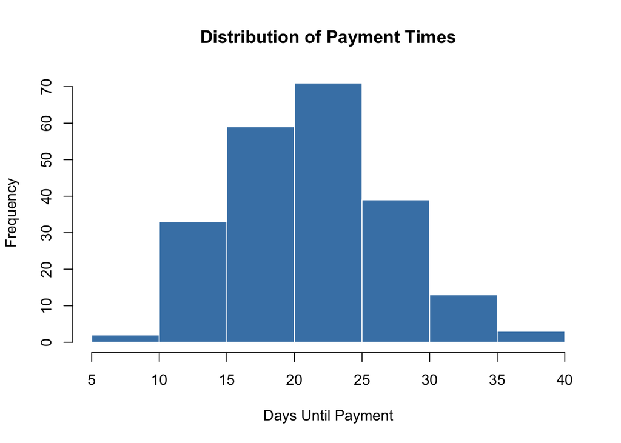

```r
# Histogram of payment times
hist(SSA$Payment,
     main = "Distribution of Payment Times",
     xlab = "Days Until Payment",
     col = "steelblue",
     border = "white")
```

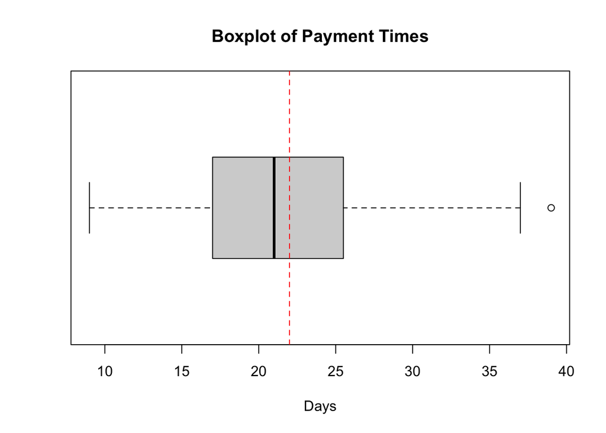

```r
# Boxplot with reference line at mu = 22
y <- SSA$Payment
boxplot(y,
        horizontal = TRUE,
        main = "Boxplot of Payment Times",
        xlab = "Days",
        col = "lightgray")
abline(v = 22, col = "red", lty = 2)
```

## Hypothesis Setup

The CFO wants to test if including a stamped self-addressed envelope reduces payment time below 22 days. If true, this would justify the cost.

- Null Hypothesis (H0): Mean payment time >= 22 days (no profit)
- Alternative Hypothesis (H1): Mean payment time < 22 days (profitable)

This is a one-tailed t-test using the sample data.

## Hypothesis Testing

```r
# One-sample t-test
t.test(SSA$Payment, alternative = "less", mu = 22)
```

```
##
##  One Sample t-test
##
## data:  SSA$Payment
## t = -0.93585, df = 219, p-value = 0.1752
## alternative hypothesis: true mean is less than 22
## 95 percent confidence interval:
##      -Inf 22.28168
## sample estimates:
## mean of x
##  21.63182
```

## Interpretation

### Type I and Type II Errors

- **Type I Error (False Positive)**:
  - Rejecting the null hypothesis when it is actually true.
  - In this case: Concluding that SSA envelopes are profitable when they are not.
  - Business consequence: Implementing the envelope plan, incurring additional costs without seeing the expected benefit.
- **Type II Error (False Negative)**:
  - Failing to reject the null hypothesis when it is actually false.
  - In this case: Missing the opportunity to implement a potentially effective low-cost intervention.
  - Business consequence: Not adopting the plan and continuing to wait longer for payments, losing potential gains in cash flow.

If the p-value is less than 0.10 (our chosen significance level), we reject the null hypothesis and conclude the SSA envelope reduces payment time below the profitability threshold.

In this case, the p-value is greater than 0.10, so we fail to reject the null hypothesis. There is insufficient evidence to recommend implementing the policy — but the approach remains a useful framework for future decision-making.

## Reflection

This project blends statistical testing with operational decision-making. It emphasizes how Type I and Type II error framing can influence business strategy, especially in low-cost, high-frequency decisions like payment operations.

Future enhancements include expanding the sample or testing the intervention through a randomized experiment to better assess its operational impact.